# Investigating Relatedness Among WGR Samples

Kyle Forgot to Filter out FS and HS Relationships from Dyads…

Kyle Shedd

2023-06-01

# Setup

Clean directory and load packages

# Objective

The objective of this notebooks is to look for full-sibling (FS) and/or half-sibling (HS) relationships among individuals from the “pedigree-assisted”, natural-homing fish from Question Set B for Stockdale 2015 & 2016 and Hogan Bay 2015 & 2016. I attempted to limit my selection to offspring from NN crosses (triads), and only select 1 fish per `mating_id`, however, in instances were there were not enough samples I had to select offspring from natural-origin parents (dyads). Critically, and mistakenly, I neglected to limit those selections to a single `parent_id`, so we ended up with some FS or HS relationships.

# Background

During a Teams meeting for an update on even-lineage genotyping and analysis on 2023-06-01 Will Hemstrom noted that there were some outliers with Hogan 2016, likely due to relatedness. I took a quick look at `extraction_list.Rmd` and noticed that I’d failed to exclude dyads that had the same `parent_id`. This R Notebook is a more formal investigation of this oversight so I can provide Will with the relatedness information for Hogan 2016 and give him a heads up as to what he should expect for the odd-lineage Stockdale 2015 and Hogan 2015.

This project is using leftover Pink Salmon Disaster 2016 funds to try to address questions about potential genetic mechanisms causing reduced RRS. This project is broken into two main questions:

- A - genomic evidence for domestication selection over time (comparing historical vs. contemporary vs. brood source collections)
- B - genomic differences between hatchery strays vs. natural-origin homing individuals

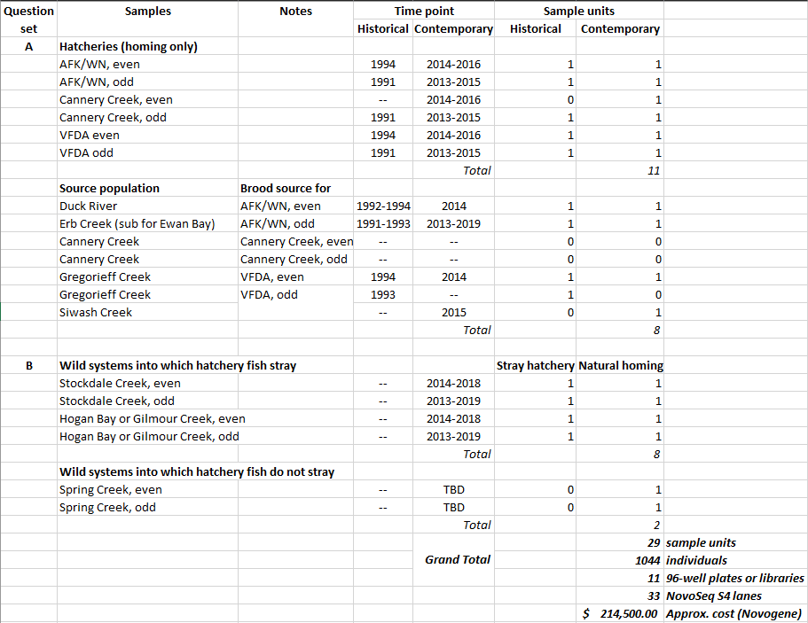

Screenshot of sample design

# Import Data

## WGR Sample Selection

Load which samples we selected for WGR

```r
(extraction_PSTOCK16_natural <- readr::read_csv(file = "../output/extraction_PSTOCK16_natural.csv", show_col_types = FALSE))
```

| silly_source | silly | fish_id | dwp_barcode | dwp_well | tissue_type | sample_date | sex | otolith_mark_present |
| --- | --- | --- | --- | --- | --- | --- | --- | --- |
| PSTOCK16_878 | PSTOCK16 | 878 | 0000015790 | 47 | Heart-bulbus arteriosus | 2016-09-04 | Female | NO |
| PSTOCK16_1038 | PSTOCK16 | 1038 | 0000015892 | 32 | Heart-bulbus arteriosus | 2016-09-11 | Male | NO |
| PSTOCK16_1085 | PSTOCK16 | 1085 | 0000014555 | 42 | Heart-bulbus arteriosus | 2016-08-23 | Male | NO |
| PSTOCK16_1193 | PSTOCK16 | 1193 | 0000014550 | 6 | Heart-bulbus arteriosus | 2016-08-23 | Male | NO |
| PSTOCK16_1321 | PSTOCK16 | 1321 | 0000014623 | 38 | Heart-bulbus arteriosus | 2016-08-31 | Male | NO |
| PSTOCK16_1799 | PSTOCK16 | 1799 | 0000014615 | 47 | Heart-bulbus arteriosus | 2016-08-31 | Female | NO |
| PSTOCK16_2018 | PSTOCK16 | 2018 | 0000015785 | 26 | Heart-bulbus arteriosus | 2016-09-04 | Female | NO |
| PSTOCK16_2441 | PSTOCK16 | 2441 | 0000014587 | 47 | Heart-bulbus arteriosus | 2016-08-29 | Male | NO |
| PSTOCK16_2588 | PSTOCK16 | 2588 | 0000014580 | 2 | Heart-bulbus arteriosus | 2016-08-29 | Male | NO |
| PSTOCK16_2764 | PSTOCK16 | 2764 | 0000014538 | 34 | Heart-bulbus arteriosus | 2016-08-22 | Female | NO |

[output cut: 26 more lines]

```r
extraction_PSTOCK15_natural <- readr::read_csv(file = "../output/extraction_PSTOCK15_natural.csv", show_col_types = FALSE)
extraction_PHOGAN16_natural <- readr::read_csv(file = "../output/extraction_PHOGAN16_natural.csv", show_col_types = FALSE)
extraction_PHOGAN15_natural <- readr::read_csv(file = "../output/extraction_PHOGAN15_natural.csv", show_col_types = FALSE)
```